# Is plot density important?

Eric R. Scott

2022-05-24

*Last compiled: 2022-05-24*

# 1 Purpose

The continuous forest plots are not sampled randomly. The first three plots (CF-1–3) have a much higher density of plants than the 1-ha fragments. Emilio then purposefully saught out low-density continuous forest plots with numbers of plants comparable to the plots in 1-ha fragments (CF-4–6). Some preliminary investigation leads me to believe the high and low density plots may be different in terms of observed population growth, vital rates, and lambda. I’ve fit the vital rates models and ran the IPMs using only low-density CF plots for comparison.

# 2 Load Data

```r
withr::with_dir(here::here(), {
  tar_load(c(
    lambda_table,
    ipm_det_cf_low,
    ipm_stoch_cf_low,
    ipm_dlnm_cf_low,
    data_full
  ))
})
```

# 3 Vital rates

One simple way to look for differences is to fit vital rates models with different smooths for 1-ha, CF-low density, and cf-high density. The `by = hab_dens` argument in `s()` generates a different smooth for each level of habitat/density

#### 3.0.0.1 NOTE:

```r
# data_full$habitat %>% unique()
df <-
  data_full %>%
  select(-L, -spei_history) %>%
  filter(year != 2000) %>%
  mutate(hab_dens = case_when(
    habitat == "1-ha" ~ "1-ha",
    plot %in% c("CF-1", "CF-2", "CF-3") ~ "CF-high",
    plot %in% c("CF-4", "CF-5", "CF-6") ~ "CF-low",
    TRUE ~ NA_character_
  ), .after = habitat) %>%
  mutate(hab_dens = as.factor(hab_dens))
```

## 3.1 Survival

Fit the model with different intercepts and smooths for the three habitat:density combos

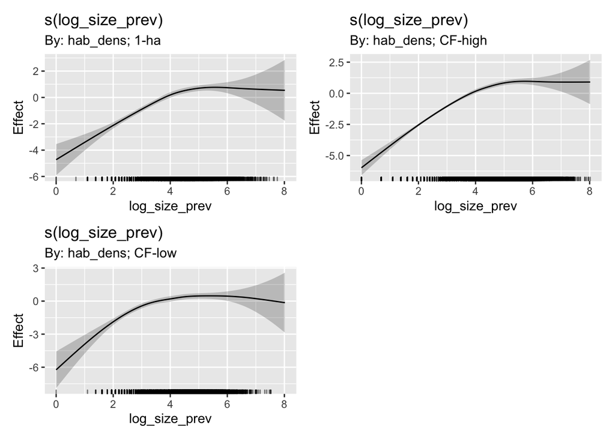

```r
m_surv <- bam(
    surv ~ hab_dens + s(log_size_prev, bs = "cr", k = 20, by = hab_dens),
    family = binomial,
    data = df %>% filter(sdlg_prev == FALSE),
    method = "fREML"
)
draw(m_surv)
```

Look at the pairwise differences in these smooths:

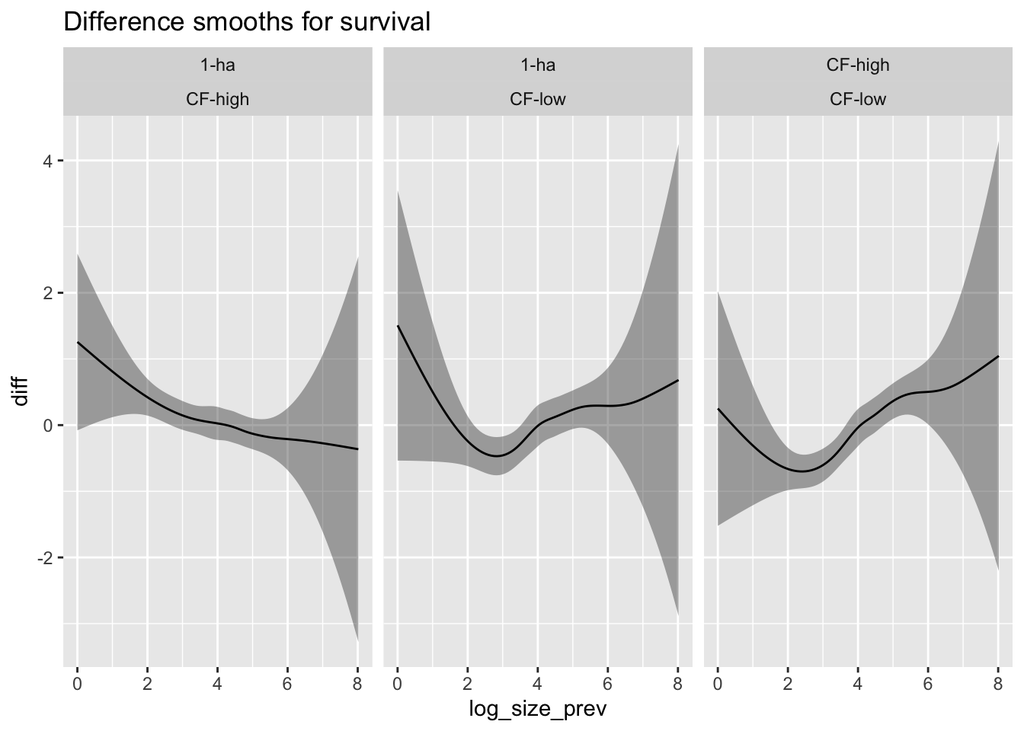

```r
diff_surv <- difference_smooths(m_surv, "s(log_size_prev)")
ggplot(diff_surv, aes(x = log_size_prev, y = diff)) +
  geom_ribbon(aes(ymin = lower, ymax = upper), alpha = 0.4) +
  geom_line() +
  facet_wrap(level_1 ~ level_2) +
  labs(title = "Difference smooths for survival")
```

Calculate contrast, the mean difference between adjusted predictions (See [vignette](https://vincentarelbundock.github.io/marginaleffects/articles/mfx02_contrasts.html)). The important thing to get about how these work is they evaluate the model at values in the actual dataset, then average the differences.

```r
cmp_surv <- comparisons(m_surv, variables = list(hab_dens = "pairwise"))
summary(cmp_surv)
```

```
## Average contrasts
##       Term         Contrast    Effect Std. Error z value  Pr(>|z|)      2.5 %
## 1 hab_dens   CF-high - 1-ha  0.004397   0.002623   1.676 0.0936489 -0.0007436
## 2 hab_dens    CF-low - 1-ha -0.006197   0.003969  -1.561 0.1184363 -0.0139750
## 3 hab_dens CF-low - CF-high -0.010594   0.003461  -3.061 0.0022069 -0.0173774
##      97.5 %
## 1  0.009538
## 2  0.001582
## 3 -0.003810
##
## Model type:  bam
## Prediction type:  response
```

The mean difference in survival between low and high density CF is significant, and the mean difference between low density CF and 1-ha is not significant.

## 3.2 Size

Fit the model with different intercepts and smooths for the three habitat:density combos

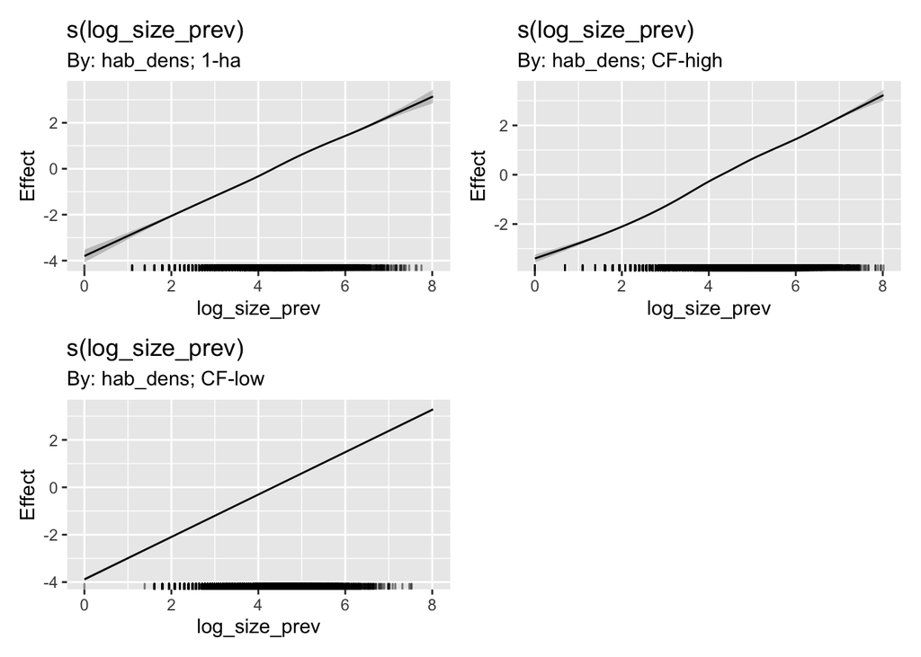

```r
m_size <- bam(
    log_size ~ hab_dens + s(log_size_prev, bs = "cr", k = 20, by = hab_dens),
    family = scat,
    data = df %>% filter(sdlg_prev == FALSE, surv == 1, !is.na(log_size)),
    method = "fREML"
)
draw(m_size)
```

Look at the pairwise differences in these smooths:

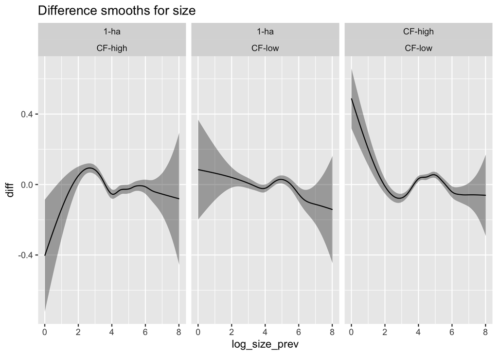

```r
diff_size <- difference_smooths(m_size, "s(log_size_prev)")
ggplot(diff_size, aes(x = log_size_prev, y = diff)) +
  geom_ribbon(aes(ymin = lower, ymax = upper), alpha = 0.4) +
  geom_line() +
  facet_wrap(level_1 ~ level_2) +
  labs(title = "Difference smooths for size")
```

differences are very minor

Contrasts:

```r
cmp_size <- comparisons(m_size, variables = list(hab_dens = "pairwise"))
summary(cmp_size)
```

```
## Average contrasts
##       Term         Contrast    Effect Std. Error z value Pr(>|z|)    2.5 %
## 1 hab_dens   CF-high - 1-ha -0.003337   0.007224  -0.462 0.644087 -0.01750
## 2 hab_dens    CF-low - 1-ha -0.023973   0.010665  -2.248 0.024590 -0.04488
## 3 hab_dens CF-low - CF-high -0.020636   0.009341  -2.209 0.027159 -0.03894
##      97.5 %
## 1  0.010821
## 2 -0.003070
## 3 -0.002328
##
## Model type:  bam
## Prediction type:  response
```

Here the CF high and 1-ha are not significantly different but other comparisons are. The smooths for CF-high and 1-ha look really different for small plants, but because there are few small plants the comparison above shows a small effect.

## 3.3 Flowering

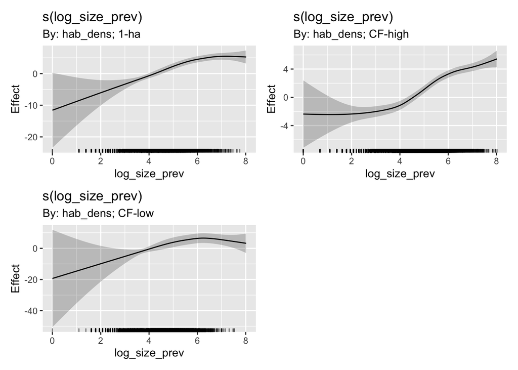

```r
m_flwr <- bam(
    flwr ~ hab_dens + s(log_size_prev, bs = "cr", k = 20, by = hab_dens),
    family = binomial,
    data = df %>% filter(sdlg == FALSE, surv == 1, !is.na(log_size)),
    method = "fREML"
  )
draw(m_flwr)
```

The smooth for high density CF looks differen than the other two.

Look at the pairwise differences in these smooths:

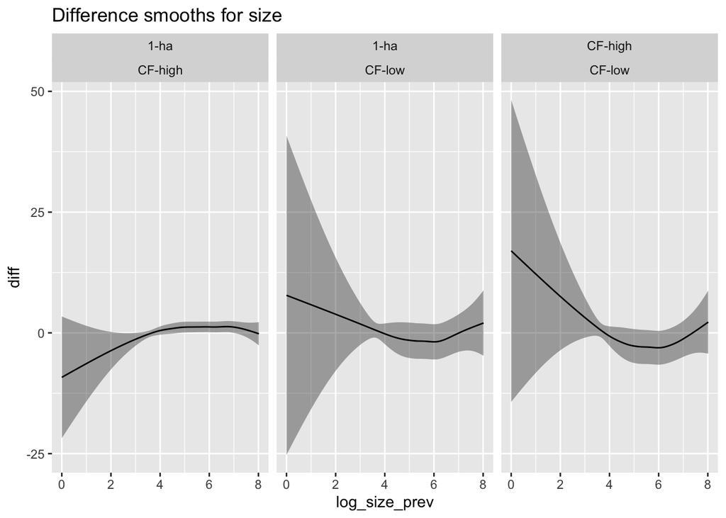

```r
diff_flwr <- difference_smooths(m_flwr, "s(log_size_prev)")
ggplot(diff_flwr, aes(x = log_size_prev, y = diff)) +
  geom_ribbon(aes(ymin = lower, ymax = upper), alpha = 0.4) +
  geom_line() +
  facet_wrap(level_1 ~ level_2) +
  labs(title = "Difference smooths for size")
```

Contrasts:

```r
cmp_flwr <- comparisons(m_flwr, variables = list(hab_dens = "pairwise"))
summary(cmp_flwr)
```

```
## Average contrasts
##       Term         Contrast    Effect Std. Error z value   Pr(>|z|)    2.5 %
## 1 hab_dens   CF-high - 1-ha -0.009651   0.002988  -3.229  0.0012405 -0.01551
## 2 hab_dens    CF-low - 1-ha -0.020564   0.004178  -4.921 8.5958e-07 -0.02875
## 3 hab_dens CF-low - CF-high -0.010913   0.003353  -3.255  0.0011356 -0.01749
##      97.5 %
## 1 -0.003794
## 2 -0.012374
## 3 -0.004341
##
## Model type:  bam
## Prediction type:  response
```

all pairwise comparisons are significantly different and the biggest difference is actually between CF-low and 1-ha

#IPMs

We can also look at the level of the IPMs

```r
lambda_table %>%
  add_row(ipm = "det", habitat = "cf_low", est = lambda(ipm_det_cf_low)) %>%
  add_row(ipm = "stoch", habitat = "cf_low", est = lambda(ipm_stoch_cf_low, log = FALSE)) %>%
  add_row(ipm = "dlnm", habitat = "cf_low", est = lambda(ipm_dlnm_cf_low, log = FALSE)) %>%
  add_row(ipm = "dlnm", habitat = "ff", est = lambda(tar_read(ipm_dlnm_ff), log = FALSE)) %>%
  add_row(ipm = "dlnm", habitat = "cf", est = lambda(tar_read(ipm_dlnm_cf), log = FALSE)) %>%
  arrange(ipm, habitat)
```

```
## # A tibble: 9 × 5
##   ipm   habitat   est  lower  upper
##   <chr> <chr>   <dbl>  <dbl>  <dbl>
## 1 det   cf      0.990  0.988  0.992
## 2 det   cf_low  0.971 NA     NA
## 3 det   ff      0.978  0.974  0.982
## 4 dlnm  cf      0.980 NA     NA
## 5 dlnm  cf_low  0.978 NA     NA
## 6 dlnm  ff      0.959 NA     NA
## 7 stoch cf      0.991  0.989  0.994
## 8 stoch cf_low  0.959 NA     NA
## 9 stoch ff      0.979  0.974  0.984
```

For the deterministic and stochastic, kernel-resampled (random effect of year) models, CF low density plots have the lowest lambda. For the DLNM IPM, CF and CF low density are comparable and FF has the lowest lambda. The caveat is that the stochastic, kernel-resampled IPM for cf_low is iterated using a different sequence of years since it doesn’t have data for 2000 or 2001.